# AIRLINE PASSENGERS SATISFACTION

# Research Questions

1. What factor leads to customer satisfaction fpr an Airline?
2. Does Passenger class determines customers satisfaction?

# Research Objectives

The Objectives of the study are to:

1. investigate the relationship between customers satisfcation and gender
2. determine if theres any association between passengers class and satisfaction
3. investigate the association among Age, Flight distance, Departure and Arrival delay
4. test if theres difference in the mean age of male and female customers
5. test if arrival delay and departure delay are statistically significance
6. make a prediction equation for predicting arrival time with respect to departure time in minutes
7. visualize all the factors and compare with customers satisfaction

# Research Hypothesis

The Null Hpothesis for this research are:

1. H0: There is no significance relationship between cuatomer satisfaction and gender
2. H0: There is no association between passengers class and satisfaction
3. H0: there is no association among all the scale factor
4. H0: there is no significnace difference between the mean age of male and female customers
5. H0: there is no significance relationship between arrival delay and departure delay

This dataset contains an airline passenger satisfaction survey. What factors are highly correlated to a satisfied (or dissatisfied) passenger? Can you predict passenger satisfaction?

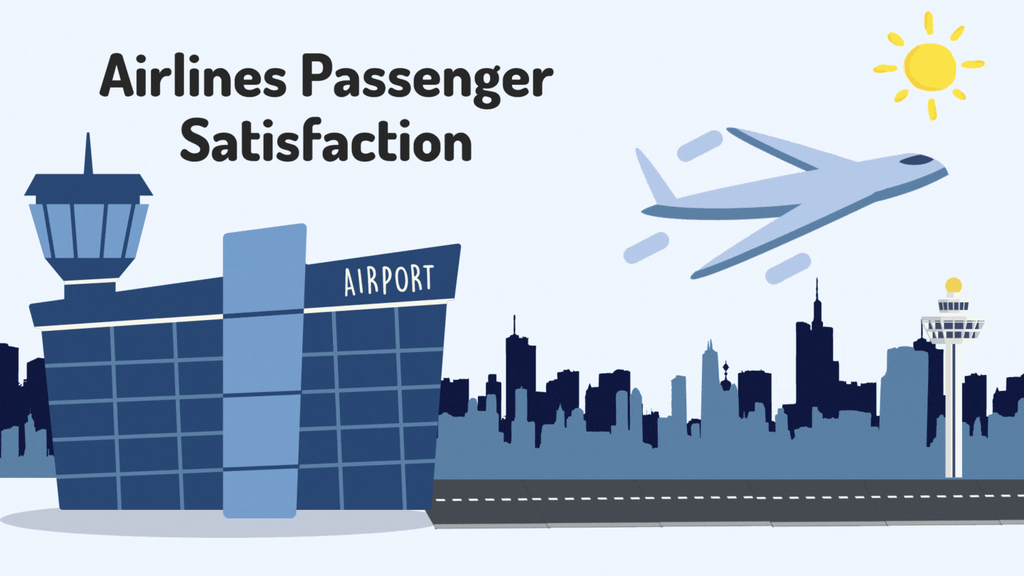

## **About the dataset**

**There is the following information about the passengers of some airline:**

1. **Gender:** male or female
2. **Customer type:** regular or non-regular airline customer
3. **Age:** the actual age of the passenger
4. **Type of travel:** the purpose of the passenger's flight (personal or business travel)
5. **Class:** business, economy, economy plus
6. **Flight distance**
7. **Inflight wifi service:** satisfaction level with Wi-Fi service on board (0: not rated; 1-5)
8. **Departure/Arrival time convenient:** departure/arrival time satisfaction level (0: not rated; 1-5)
9. **Ease of Online booking:** online booking satisfaction rate (0: not rated; 1-5)
10. **Gate location:** level of satisfaction with the gate location (0: not rated; 1-5)
11. **Food and drink:** food and drink satisfaction level (0: not rated; 1-5)
12. **Online boarding:** satisfaction level with online boarding (0: not rated; 1-5)
13. **Seat comfort:** seat satisfaction level (0: not rated; 1-5)
14. **Inflight entertainment:** satisfaction with inflight entertainment (0: not rated; 1-5)
15. **On-board service:** level of satisfaction with on-board service (0: not rated; 1-5)
16. **Leg room service**: level of satisfaction with leg room service (0: not rated; 1-5)
17. **Baggage handling:** level of satisfaction with baggage handling (0: not rated; 1-5)
18. **Checkin service:** level of satisfaction with checkin service (0: not rated; 1-5)
19. **Inflight service:** level of satisfaction with inflight service (0: not rated; 1-5)
20. **Cleanliness:** level of satisfaction with cleanliness (0: not rated; 1-5)
21. **Departure delay in minutes**
22. **Arrival delay in minutes**

This data set contains a survey on **air passenger satisfaction**. The following **classification problem** is set:

It is necessary to predict which of the **two** levels of satisfaction with the airline the passenger belongs to:

1. *Satisfaction*
2. *Neutral or dissatisfied*

**Dependent Varaiable:** Passanger Satisfaction, Class, Age and Arrival Time

**Independent Variables:** Gender, Cleaniless,and Departure time

```python
# Importing required packages


import numpy as np
import pandas as pd
import seaborn as sns
import matplotlib.pyplot as plt
import pandas.util.testing as tm
import researchpy as rp
import statsmodels.api as sm

from scipy.stats import chi2_contingency
from scipy.stats import stats
import statistics as st
```

## Importing the Dataset

```python
data = pd.read_csv("C:/Users/HP/Desktop/UI-LISA ANALYSIS & CODES/PROJECT ANALYSIS/Ui Clients/Mr Samuel (PYTHON)/DATA/Invistico_Airline.csv")

data.head()
```

|  | satisfaction | Gender | Customer Type | Age | Type of Travel | Class | Flight Distance | Seat comfort | Departure/Arrival time convenient | Food and drink | ... | Online support | Ease of Online booking | On-board service | Leg room service | Baggage handling | Checkin service | Cleanliness | Online boarding | Departure Delay in Minutes | Arrival Delay in Minutes |
| --- | --- | --- | --- | --- | --- | --- | --- | --- | --- | --- | --- | --- | --- | --- | --- | --- | --- | --- | --- | --- | --- |
| 0 | satisfied | Female | Loyal Customer | 65 | Personal Travel | Eco | 265 | 0 | 0 | 0 | ... | 2 | 3 | 3 | 0 | 3 | 5 | 3 | 2 | 0 | 0.0 |
| 1 | satisfied | Male | Loyal Customer | 47 | Personal Travel | Business | 2464 | 0 | 0 | 0 | ... | 2 | 3 | 4 | 4 | 4 | 2 | 3 | 2 | 310 | 305.0 |
| 2 | satisfied | Female | Loyal Customer | 15 | Personal Travel | Eco | 2138 | 0 | 0 | 0 | ... | 2 | 2 | 3 | 3 | 4 | 4 | 4 | 2 | 0 | 0.0 |
| 3 | satisfied | Female | Loyal Customer | 60 | Personal Travel | Eco | 623 | 0 | 0 | 0 | ... | 3 | 1 | 1 | 0 | 1 | 4 | 1 | 3 | 0 | 0.0 |
| 4 | satisfied | Female | Loyal Customer | 70 | Personal Travel | Eco | 354 | 0 | 0 | 0 | ... | 4 | 2 | 2 | 0 | 2 | 4 | 2 | 5 | 0 | 0.0 |

5 rows × 23 columns

## Running some Data cleaning

```python
data.describe()
```

|  | Age | Flight Distance | Seat comfort | Departure/Arrival time convenient | Food and drink | Gate location | Inflight wifi service | Inflight entertainment | Online support | Ease of Online booking | On-board service | Leg room service | Baggage handling | Checkin service | Cleanliness | Online boarding | Departure Delay in Minutes | Arrival Delay in Minutes |
| --- | --- | --- | --- | --- | --- | --- | --- | --- | --- | --- | --- | --- | --- | --- | --- | --- | --- | --- |
| count | 129880.000000 | 129880.000000 | 129880.000000 | 129880.000000 | 129880.000000 | 129880.000000 | 129880.000000 | 129880.000000 | 129880.000000 | 129880.000000 | 129880.000000 | 129880.000000 | 129880.000000 | 129880.000000 | 129880.000000 | 129880.000000 | 129880.000000 | 129487.000000 |
| mean | 39.427957 | 1981.409055 | 2.838597 | 2.990645 | 2.851994 | 2.990422 | 3.249130 | 3.383477 | 3.519703 | 3.472105 | 3.465075 | 3.485902 | 3.695673 | 3.340807 | 3.705759 | 3.352587 | 14.713713 | 15.091129 |
| std | 15.119360 | 1027.115606 | 1.392983 | 1.527224 | 1.443729 | 1.305970 | 1.318818 | 1.346059 | 1.306511 | 1.305560 | 1.270836 | 1.292226 | 1.156483 | 1.260582 | 1.151774 | 1.298715 | 38.071126 | 38.465650 |
| min | 7.000000 | 50.000000 | 0.000000 | 0.000000 | 0.000000 | 0.000000 | 0.000000 | 0.000000 | 0.000000 | 0.000000 | 0.000000 | 0.000000 | 1.000000 | 0.000000 | 0.000000 | 0.000000 | 0.000000 | 0.000000 |
| 25% | 27.000000 | 1359.000000 | 2.000000 | 2.000000 | 2.000000 | 2.000000 | 2.000000 | 2.000000 | 3.000000 | 2.000000 | 3.000000 | 2.000000 | 3.000000 | 3.000000 | 3.000000 | 2.000000 | 0.000000 | 0.000000 |
| 50% | 40.000000 | 1925.000000 | 3.000000 | 3.000000 | 3.000000 | 3.000000 | 3.000000 | 4.000000 | 4.000000 | 4.000000 | 4.000000 | 4.000000 | 4.000000 | 3.000000 | 4.000000 | 4.000000 | 0.000000 | 0.000000 |
| 75% | 51.000000 | 2544.000000 | 4.000000 | 4.000000 | 4.000000 | 4.000000 | 4.000000 | 4.000000 | 5.000000 | 5.000000 | 4.000000 | 5.000000 | 5.000000 | 4.000000 | 5.000000 | 4.000000 | 12.000000 | 13.000000 |
| max | 85.000000 | 6951.000000 | 5.000000 | 5.000000 | 5.000000 | 5.000000 | 5.000000 | 5.000000 | 5.000000 | 5.000000 | 5.000000 | 5.000000 | 5.000000 | 5.000000 | 5.000000 | 5.000000 | 1592.000000 | 1584.000000 |

```python
print(data.shape)
print(data.columns)
```

```
(129880, 23)
Index(['satisfaction', 'Gender', 'Customer Type', 'Age', 'Type of Travel',
       'Class', 'Flight Distance', 'Seat comfort',
       'Departure/Arrival time convenient', 'Food and drink', 'Gate location',
       'Inflight wifi service', 'Inflight entertainment', 'Online support',
       'Ease of Online booking', 'On-board service', 'Leg room service',
       'Baggage handling', 'Checkin service', 'Cleanliness', 'Online boarding',
       'Departure Delay in Minutes', 'Arrival Delay in Minutes'],
      dtype='object')
```

```python
data.info()
```

```
<class 'pandas.core.frame.DataFrame'>
RangeIndex: 129880 entries, 0 to 129879
Data columns (total 23 columns):
 #   Column                             Non-Null Count   Dtype
---  ------                             --------------   -----
 0   satisfaction                       129880 non-null  object
 1   Gender                             129880 non-null  object
 2   Customer Type                      129880 non-null  object
 3   Age                                129880 non-null  int64
 4   Type of Travel                     129880 non-null  object
 5   Class                              129880 non-null  object
 6   Flight Distance                    129880 non-null  int64
 7   Seat comfort                       129880 non-null  int64
 8   Departure/Arrival time convenient  129880 non-null  int64
 9   Food and drink                     129880 non-null  int64
 10  Gate location                      129880 non-null  int64
 11  Inflight wifi service              129880 non-null  int64
 12  Inflight entertainment             129880 non-null  int64
 13  Online support                     129880 non-null  int64
 14  Ease of Online booking             129880 non-null  int64
 15  On-board service                   129880 non-null  int64
 16  Leg room service                   129880 non-null  int64
 17  Baggage handling                   129880 non-null  int64
 18  Checkin service                    129880 non-null  int64
 19  Cleanliness                        129880 non-null  int64
 20  Online boarding                    129880 non-null  int64
 21  Departure Delay in Minutes         129880 non-null  int64
 22  Arrival Delay in Minutes           129487 non-null  float64
dtypes: float64(1), int64(17), object(5)
memory usage: 22.8+ MB
```

## Converting all rating columns to categories

```python
categorical_indexes = [0,1,2,4,5] + list(range(7, 21))
print(categorical_indexes)
data.iloc[:,categorical_indexes] = data.iloc[:,categorical_indexes].astype('category')
```

```
[0, 1, 2, 4, 5, 7, 8, 9, 10, 11, 12, 13, 14, 15, 16, 17, 18, 19, 20]
```

```python
data.info()
```

```
<class 'pandas.core.frame.DataFrame'>
RangeIndex: 129880 entries, 0 to 129879
Data columns (total 23 columns):
 #   Column                             Non-Null Count   Dtype
---  ------                             --------------   -----
 0   satisfaction                       129880 non-null  category
 1   Gender                             129880 non-null  category
 2   Customer Type                      129880 non-null  category
 3   Age                                129880 non-null  int64
 4   Type of Travel                     129880 non-null  category
 5   Class                              129880 non-null  category
 6   Flight Distance                    129880 non-null  int64
 7   Seat comfort                       129880 non-null  category
 8   Departure/Arrival time convenient  129880 non-null  category
 9   Food and drink                     129880 non-null  category
 10  Gate location                      129880 non-null  category
 11  Inflight wifi service              129880 non-null  category
 12  Inflight entertainment             129880 non-null  category
 13  Online support                     129880 non-null  category
 14  Ease of Online booking             129880 non-null  category
 15  On-board service                   129880 non-null  category
 16  Leg room service                   129880 non-null  category
 17  Baggage handling                   129880 non-null  category
 18  Checkin service                    129880 non-null  category
 19  Cleanliness                        129880 non-null  category
 20  Online boarding                    129880 non-null  category
 21  Departure Delay in Minutes         129880 non-null  int64
 22  Arrival Delay in Minutes           129487 non-null  float64
dtypes: category(19), float64(1), int64(3)
memory usage: 6.3 MB
```

### Checking for missing data

```python
data.isna().sum()
```

```
satisfaction                           0
Gender                                 0
Customer Type                          0
Age                                    0
Type of Travel                         0
Class                                  0
Flight Distance                        0
Seat comfort                           0
Departure/Arrival time convenient      0
Food and drink                         0
Gate location                          0
Inflight wifi service                  0
Inflight entertainment                 0
Online support                         0
Ease of Online booking                 0
On-board service                       0
Leg room service                       0
Baggage handling                       0
Checkin service                        0
Cleanliness                            0
Online boarding                        0
Departure Delay in Minutes             0
Arrival Delay in Minutes             393
dtype: int64
```

### Filling the missing data with the median of the column

```python
data['Arrival Delay in Minutes'].fillna(data['Arrival Delay in Minutes'].median(axis = 0), inplace = True)
```

```python
data.isna().sum()
```

```
satisfaction                         0
Gender                               0
Customer Type                        0
Age                                  0
Type of Travel                       0
Class                                0
Flight Distance                      0
Seat comfort                         0
Departure/Arrival time convenient    0
Food and drink                       0
Gate location                        0
Inflight wifi service                0
Inflight entertainment               0
Online support                       0
Ease of Online booking               0
On-board service                     0
Leg room service                     0
Baggage handling                     0
Checkin service                      0
Cleanliness                          0
Online boarding                      0
Departure Delay in Minutes           0
Arrival Delay in Minutes             0
dtype: int64
```

## EXPLORATORY DATA ANALYSIS (EDA)

### What is EDA?

Exploratory Data Analysis: this is unavoidable and one of the major step to fine-tune the given data set(s) in a different form of analysis to understand the insights of the key characteristics of various entities of the data set like column(s), row(s) by applying Pandas, NumPy, Statistical Methods, and Data visualization packages.

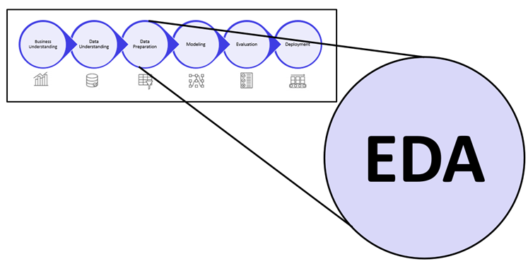

we can see from the data information above that, the rating colums has been succesfully converted to cateogries for the purpose of analysis.

Now lets decribe the data:

### Exploratory Data Analysis

```python
data.describe()
```

|  | Age | Flight Distance | Departure Delay in Minutes | Arrival Delay in Minutes |
| --- | --- | --- | --- | --- |
| count | 129880.000000 | 129880.000000 | 129880.000000 | 129880.000000 |
| mean | 39.427957 | 1981.409055 | 14.713713 | 15.045465 |
| std | 15.119360 | 1027.115606 | 38.071126 | 38.416353 |
| min | 7.000000 | 50.000000 | 0.000000 | 0.000000 |
| 25% | 27.000000 | 1359.000000 | 0.000000 | 0.000000 |
| 50% | 40.000000 | 1925.000000 | 0.000000 | 0.000000 |
| 75% | 51.000000 | 2544.000000 | 12.000000 | 13.000000 |
| max | 85.000000 | 6951.000000 | 1592.000000 | 1584.000000 |

```python
data.describe().transpose()
```

|  | count | mean | std | min | 25% | 50% | 75% | max |
| --- | --- | --- | --- | --- | --- | --- | --- | --- |
| Age | 129880.0 | 39.427957 | 15.119360 | 7.0 | 27.0 | 40.0 | 51.0 | 85.0 |
| Flight Distance | 129880.0 | 1981.409055 | 1027.115606 | 50.0 | 1359.0 | 1925.0 | 2544.0 | 6951.0 |
| Departure Delay in Minutes | 129880.0 | 14.713713 | 38.071126 | 0.0 | 0.0 | 0.0 | 12.0 | 1592.0 |
| Arrival Delay in Minutes | 129880.0 | 15.045465 | 38.416353 | 0.0 | 0.0 | 0.0 | 13.0 | 1584.0 |

from the descriptive statistics table above, it is seen that the average passenger age is approximately 39years, with minimum and maximum age of 7 and 85years respectively, and the dispersion level of 15.12, with first quartile, median and third quartile of 27, 40 and 51 respectively.

Flight as well has an avergae distance of 1981.409 and dispersion level of 1027.11, where the minimum flight distance is 50 and the maximum flight distance is 6951.

The avergae delay in departure and arrival time is seen to be approximately the same (15minutes), along with their level of dispersion, and the maximum departure and arrival delay is 1592 and 1584 minutes respectively.

### Descriptive Statistics of Categorical colums in the dataset

```python
data.describe(include = 'category')
```

|  | satisfaction | Gender | Customer Type | Type of Travel | Class | Seat comfort | Departure/Arrival time convenient | Food and drink | Gate location | Inflight wifi service | Inflight entertainment | Online support | Ease of Online booking | On-board service | Leg room service | Baggage handling | Checkin service | Cleanliness | Online boarding |
| --- | --- | --- | --- | --- | --- | --- | --- | --- | --- | --- | --- | --- | --- | --- | --- | --- | --- | --- | --- |
| count | 129880 | 129880 | 129880 | 129880 | 129880 | 129880 | 129880 | 129880 | 129880 | 129880 | 129880 | 129880 | 129880 | 129880 | 129880 | 129880 | 129880 | 129880 | 129880 |
| unique | 2 | 2 | 2 | 2 | 3 | 6 | 6 | 6 | 6 | 6 | 6 | 6 | 6 | 6 | 6 | 5 | 6 | 6 | 6 |
| top | satisfied | Female | Loyal Customer | Business travel | Business | 3 | 4 | 3 | 3 | 4 | 4 | 4 | 4 | 4 | 4 | 4 | 4 | 4 | 4 |
| freq | 71087 | 65899 | 106100 | 89693 | 62160 | 29183 | 29593 | 28150 | 33546 | 31560 | 41879 | 41510 | 39920 | 40675 | 39698 | 48240 | 36481 | 48795 | 35181 |

the table above shows the count of each rows in the categorical columns, as well as the value that has the highest count in each categorical column along with thier frequencies.

### Comparing the average of Age, Flight Distance, Departure and Arrival Delay in minutes

```python
data.groupby('satisfaction').mean()
```

| satisfaction | Age | Flight Distance | Departure Delay in Minutes | Arrival Delay in Minutes |
| --- | --- | --- | --- | --- |
| dissatisfied | 37.466671 | 2025.709234 | 17.807749 | 18.445427 |
| satisfied | 41.050051 | 1944.770281 | 12.154768 | 12.233503 |

# DATA VISUALIZATION

## Analysis of Satisfaction

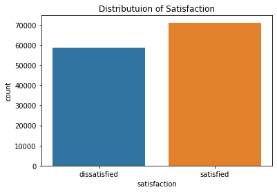

```python
sns.countplot(x ='satisfaction', data = data)
plt.title("Distributuion of Satisfaction")
plt.show()
```

```python
print((data['satisfaction'].value_counts()/len(data['satisfaction']))*100)
```

```
satisfied       54.73283
dissatisfied    45.26717
Name: satisfaction, dtype: float64
```

The above shows the frequency counts of passengers satisfaction classified and categorized into 'Dissatisfied' and 'Satisfied', where satisfied passengers seems to have the highest frequency compared to dissatisfied passengers.

## Analysis of Gender

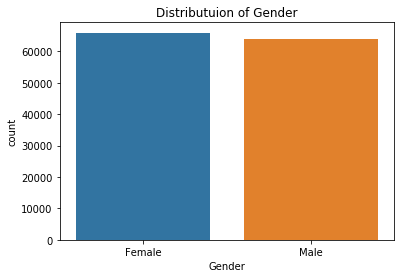

```python
sns.countplot(x ='Gender', data = data)
plt.title("Distributuion of Gender")
plt.show()
```

```python
print((data['Gender'].value_counts()/len(data['Gender']))*100)
```

```
Female    50.738374
Male      49.261626
Name: Gender, dtype: float64
```

## Analysis of Customer Type

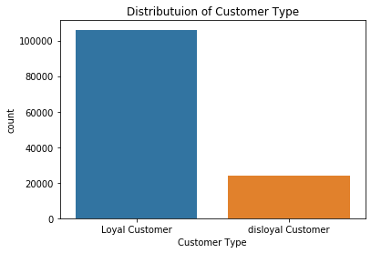

```python
sns.countplot(x ='Customer Type', data = data)
plt.title("Distributuion of Customer Type")
plt.show()
```

```python
print((data['Customer Type'].value_counts()/len(data['Customer Type']))*100)
```

```
Loyal Customer       81.690791
disloyal Customer    18.309209
Name: Customer Type, dtype: float64
```

## Analysis of Type of Travel

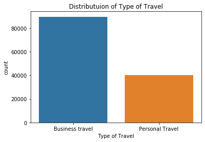

```python
sns.countplot(x ='Type of Travel', data = data)
plt.title("Distributuion of Type of Travel")
plt.show()
```

```python
print((data['Type of Travel'].value_counts()/len(data['Type of Travel']))*100)
```

```
Business travel    69.058362
Personal Travel    30.941638
Name: Type of Travel, dtype: float64
```

## Analysis of Class

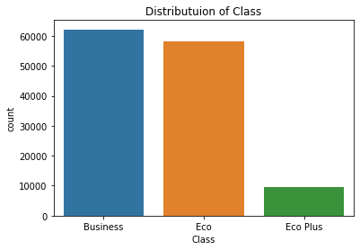

```python
sns.countplot(x ='Class', data = data)
plt.title("Distributuion of Class")
plt.show()
```

```python
print((data['Class'].value_counts()/len(data['Class']))*100)
```

```
Business    47.859563
Eco         44.894518
Eco Plus     7.245919
Name: Class, dtype: float64
```

## Analysis of Inflight wifi service

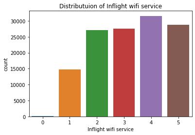

```python
sns.countplot(x ='Inflight wifi service', data = data)
plt.title("Distributuion of Inflight wifi service")
plt.show()
```

```python
print((data['Inflight wifi service'].value_counts()/len(data['Inflight wifi service']))*100)
```

```
4    24.299353
5    22.197413
3    21.251925
2    20.823067
1    11.326609
0     0.101632
Name: Inflight wifi service, dtype: float64
```

## Analysis of Departure/Arrival time convenient

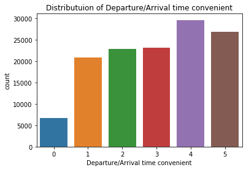

```python
sns.countplot(x ='Departure/Arrival time convenient', data = data)
plt.title("Distributuion of Departure/Arrival time convenient")
plt.show()
```

```python
print((data['Departure/Arrival time convenient'].value_counts()/len(data['Departure/Arrival time convenient']))*100)
```

```
4    22.784878
5    20.647521
3    17.850323
2    17.550046
1    16.036341
0     5.130890
Name: Departure/Arrival time convenient, dtype: float64
```

## Analysis of Ease of Online booking

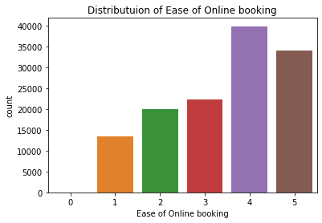

```python
sns.countplot(x ='Ease of Online booking', data = data)
plt.title("Distributuion of Ease of Online booking")
plt.show()
```

```python
print((data['Ease of Online booking'].value_counts()/len(data['Ease of Online booking']))*100)
```

```
4    30.736064
5    26.283492
3    17.260548
2    15.361103
1    10.344934
0     0.013859
Name: Ease of Online booking, dtype: float64
```

## Analysis of Gate location

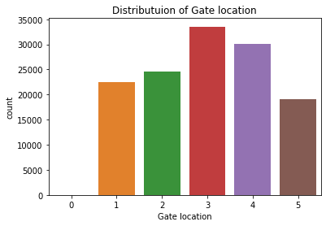

```python
sns.countplot(x ='Gate location', data = data)
plt.title("Distributuion of Gate location")
plt.show()
```

```python
print((data['Gate location'].value_counts()/len(data['Gate location']))*100)
```

```
3    25.828457
4    23.165999
2    18.877425
1    17.373730
5    14.752849
0     0.001540
Name: Gate location, dtype: float64
```

## Analysis of Food and drink

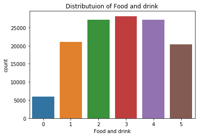

```python
sns.countplot(x ='Food and drink', data = data)
plt.title("Distributuion of Food and drink")
plt.show()
```

```python
print((data['Food and drink'].value_counts()/len(data['Food and drink']))*100)
```

```
3    21.673853
4    20.954727
2    20.900832
1    16.227287
5    15.665999
0     4.577302
Name: Food and drink, dtype: float64
```

## Analysis of Online boarding

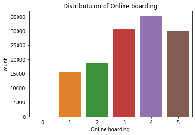

```python
sns.countplot(x ='Online boarding', data = data)
plt.title("Distributuion of Online boarding")
plt.show()
```

```python
print((data['Online boarding'].value_counts()/len(data['Online boarding']))*100)
```

```
4    27.087311
3    23.698799
5    23.077456
2    14.300123
1    11.825531
0     0.010779
Name: Online boarding, dtype: float64
```

## Analysis of Seat comfort

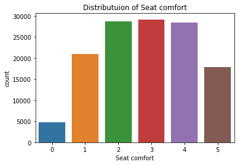

```python
sns.countplot(x ='Seat comfort', data = data)
plt.title("Distributuion of Seat comfort")
plt.show()
```

```python
print((data['Seat comfort'].value_counts()/len(data['Seat comfort']))*100)
```

```
3    22.469202
2    22.117339
4    21.864798
1    16.129504
5    13.725747
0     3.693409
Name: Seat comfort, dtype: float64
```

## Analysis of Inflight entertainment

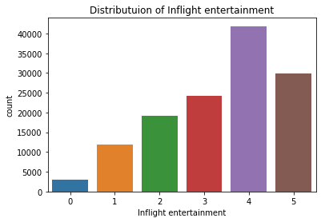

```python
sns.countplot(x ='Inflight entertainment', data = data)
plt.title("Distributuion of Inflight entertainment")
plt.show()
```

```python
print((data['Inflight entertainment'].value_counts()/len(data['Inflight entertainment']))*100)
```

```
4    32.244379
5    22.968124
3    18.632584
2    14.769787
1     9.092239
0     2.292886
Name: Inflight entertainment, dtype: float64
```

## Analysis of On-board service

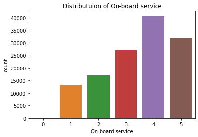

```python
sns.countplot(x ='On-board service', data = data)
plt.title("Distributuion of On-board service")
plt.show()
```

```python
print((data['On-board service'].value_counts()/len(data['On-board service']))*100)
```

```
4    31.317370
5    24.425624
3    20.816908
2    13.222975
1    10.213274
0     0.003850
Name: On-board service, dtype: float64
```